# Final Paper

STOR 320.01 Group 9

December 06, 2024

# INTRODUCTION

The stock market provides a trading network that connects investors and traders to buy and sell stocks. An understanding of this market and stock exchanges is useful for analyzing market efficiency, assessing trends in performance, and building financial literacy. In learning about stocks and investing, it can help individuals become financially literate and make educated financial choices. For investors, it can help them assess potential risks and maximize returns in their investments. Our group investigated the financial factors and variables that influence a company’s stock price and earnings per share from operations. This analysis of stock prices and current assets can provide insights into a company’s value and financial health. These insights enable investors to make informed investment decisions and companies to refine their financial planning and strategies.

Our first question asks: Is the relationship between increasingly improved earnings or other fundamental indicators effect on price completely linear or does it have an exponentially increasing effect on valuation for every additional increase? Given that external factors such as market sentiment and political events may impact stock prices, we wanted to investigate whether the effect of improved earnings or other fundamental indicators on prices can be measured by a linear relationship. Additionally, the association between earnings and price is a metric that can be used by investors and analysts to assess whether a company’s stock is overvalued or undervalued.

Our second question explores the extent to which total current assets, shares outstanding, and share prices drive change in earnings per share from operations across the leading companies in the dataset. Analyzing how stock metrics and liquidity affect earnings per share provides valuable insights into a company’s overall performance, including its financial health and profitability. This information is useful for investors and traders to determine whether they should invest in a company’s stocks and assess its potential for profit. Additionally, companies can utilize this to to identify the factors that strongly influence operational earnings per share and optimize their financial strategies. With our analysis, we seek to identify the predictors that affect earnings per share from operations and the degree of this relationship.

# DATA

For this project, our group utilized the **CRSP/Compustat Merged Database - Fundamentals Quarterly**, a dataset compiled by Standard & Poor’s and formatted for CRSPAccess by the University of Chicago Booth School of Business. The dataset provides quarterly financial data for the 30 Dow Jones Industrial (DJI) companies. It spans from the year 2000 to the third quarter of 2024, offering a comprehensive view of these companies’ financial and market performance over two decades. The CRSP/Compustat database is a widely recognized resource in academic finance research and serves as a reliable source of data for evaluating corporate fundamentals and market dynamics.

The dataset includes over 2,800 observations, each representing a specific company’s financial metrics for a given fiscal quarter. Key identifiers include the Standard and Poor’s identifier (`gvkey`) and the ticker symbol (`tic`). The dataset is not a sample but rather a census of the quarterly financial fundamentals of all 30 DJI companies over the time frame specified. The variables include stock prices, earnings per share (EPS), dividends, current assets, and other financial indicators, making it ideal for addressing our research questions on the relationship between financial metrics and stock valuation.

For our analysis, we focused on a subset of the variables relevant to our research questions:

- Earnings per Share (EPS): A measure of a company’s profitability, defined as the portion of a company’s profit allocated to each outstanding share.
- Price Close (prccq): The closing stock price for each quarter, representing market valuation.
- Earnings per Share (opepsq): Measures the profitability allocated to each outstanding share, adjusted for splits and other events.
- Current Assets (actq): Total assets available for use or liquidation within a year, reflecting liquidity.
- Common Shares Outstanding (cshoq): The total number of shares currently held by shareholders.
- Revenue (revtq): The total income generated by the company from its core business operations.
- Earnings Total (epspxq * cshprq): A calculated variable representing total earnings for the quarter, adjusted for outstanding shares.

These variables were carefully selected to address our two research questions: the relationship between fundamental indicators and stock price valuation, and the extent to which financial metrics predict operational earnings per share.

Descriptive Table: Head of Relevant Variables The descriptive table displays the first six observations of the dataset, specifically focusing on the subset of variables relevant to our research questions.

```
##     prccq opepsq   cshoq  actq epspxq
## 1 52.6875   0.64 798.161  9750   0.64
## 2 33.6875   0.76 801.051  9851   0.77
## 3 35.6250   0.76 797.486 11186   0.35
## 4 47.3125   0.71 807.292 10661   0.32
## 5 40.8000   0.51 809.281 10291   0.05
## 6 34.9900   0.55 811.616 10316   0.06
```

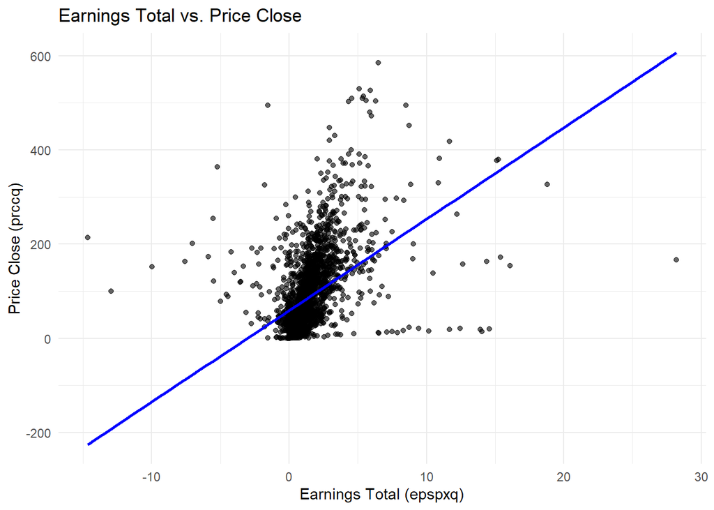

# RESULTS

### Question 1: Is the relationship between increasingly improved earnings or other fundamental indicators effect on price completely linear or does it have an exponentially increasing effect on valuation for every additional increase?

To start off, we need to do some data cleaning and pull out any identifier variables. In addition to this, we make sure to adjust our outcome variable prccq (close price) with the adjustment factor necessary, and a few other variables, to make the analysis of a company’s valuation between different periods consistent. After this to eliminate NAs we set all empty spaces to being the mean of the column, which will deal with empty cells but may decrease the variance of our predictions. In addition to the provided columns, we add a “earnings_total” variable, which is the total earnings for that quarter (Shares times earnings per share) and opepsq_qtr, which is similarly the earnings from operations for the quarter as a whole.

With +600 explanatory variables, we chose to isolate the most important fundamental variables for this analysis using a shrinkage method, in particular, LASSO. After analyzing the results of a 10-fold CV analysis, we find an alpha of 0.6 and a lambda 1.306013 to be optimal (as measured by MSE). Using these parameters we end up isolating 120 of the most relevant fundamental predictors.

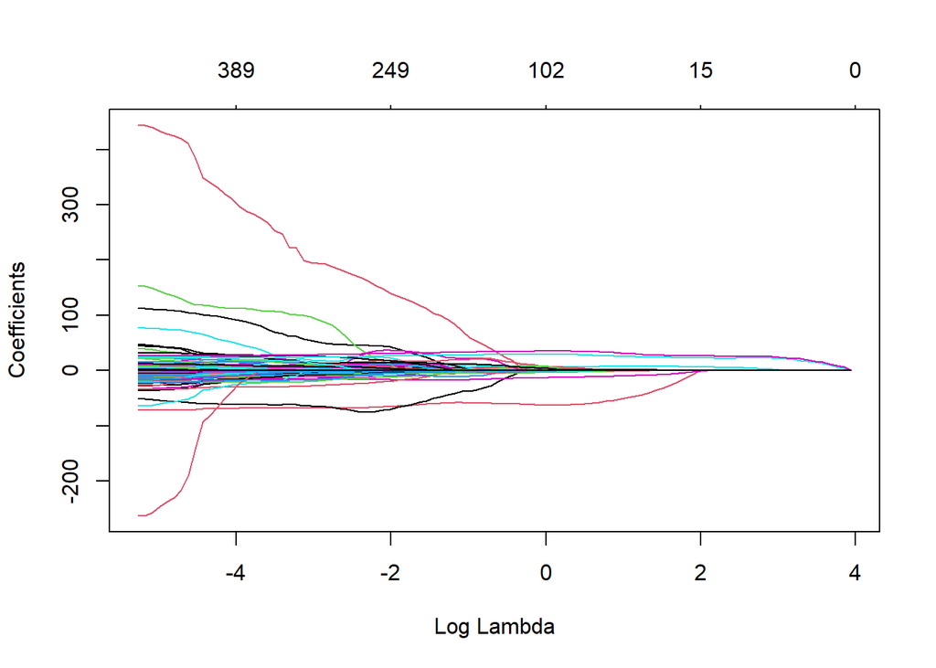

```
##   alpha   lambda      MSE
## 1   0.6 1.306013 721.5402
## 2   0.8 1.075010 740.0634
## 3   0.7 1.348369 766.0695
## 4   0.5 1.887716 770.3256
## 5   0.9 1.150981 790.4806
```

To examine this question we will complete a polynomial regression on our data, matching certain notable fundamental indicators, many of which are very important in financial analysis for company valuation (factors such as Cost of Goods sold, Cash Dividends, Earnings per share, etc). This will show us whether these fundamental factors have more than a linear relationship between themselves and the close price of the security, and the particular polynomial can show the rate of increase/decrease. Our isolated set of predictive factors provides negligible increases to R-Squared after adding the 6th polynomial.

The graph “Coefficient size by Variable as Polynomial Increases” takes our coefficients for model 6 and separates each lines as a distinct variable, then plots the coefficient size (and sign) as the polynomial for that coefficient increases (ie, opepsq^1, opepsq^2, etc). What we find is that many of the variables do not vary all that much, or actually exhibit a decrease in coefficient size. For some variables however, our initial inquiry seems to be validated, since the coefficients of the larger polynomials of some variables are much larger than the coefficient of their respective lower polynomial counterparts.

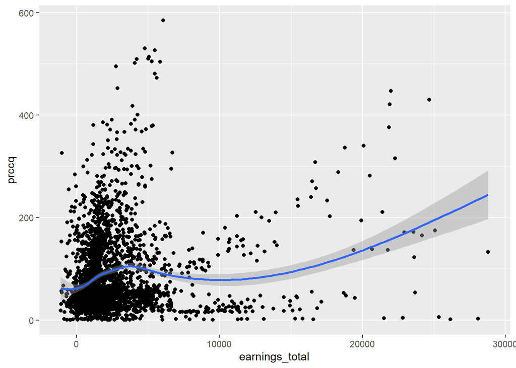

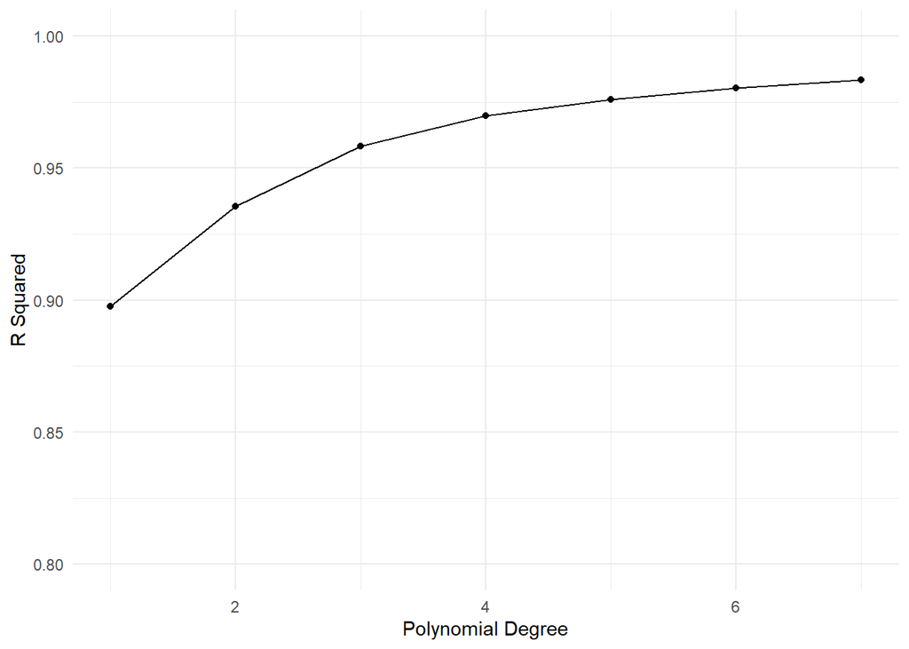

```
##                     Coefficient             Name variable_name polynomial
## `prcepsq_power_^2`  10770369.11 prcepsq_power_^2       prcepsq          2
## `prcdq_power_^2`   -10765944.59   prcdq_power_^2         prcdq          2
## `capr3q_power_^2`     -43835.61  capr3q_power_^2        capr3q          2
## `capr1q_power_^2`      27473.61  capr1q_power_^2        capr1q          2
## `dtedy_power_^2`       23788.13   dtedy_power_^2         dtedy          2
```

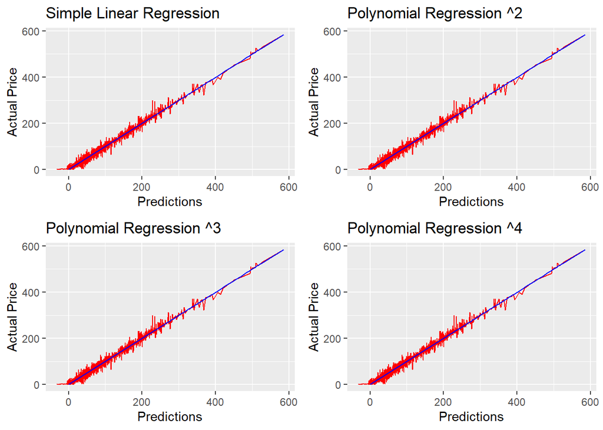

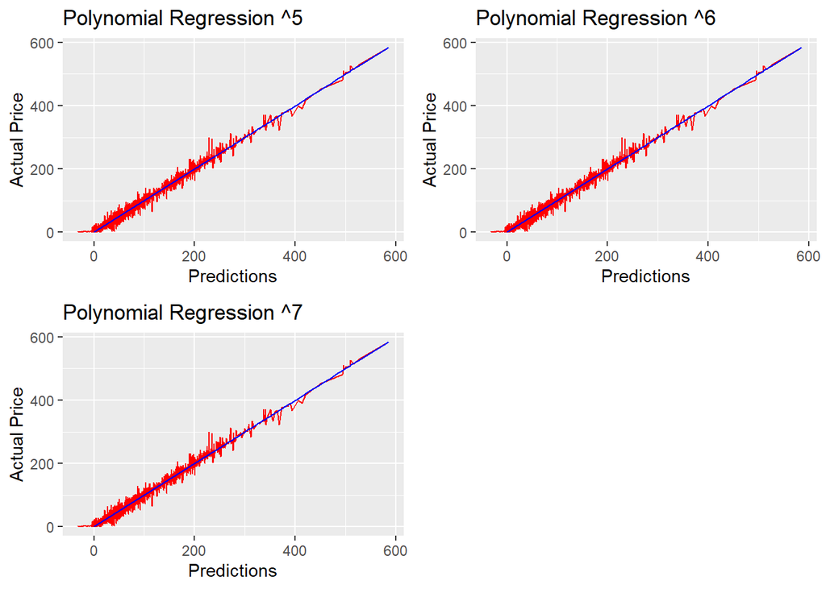

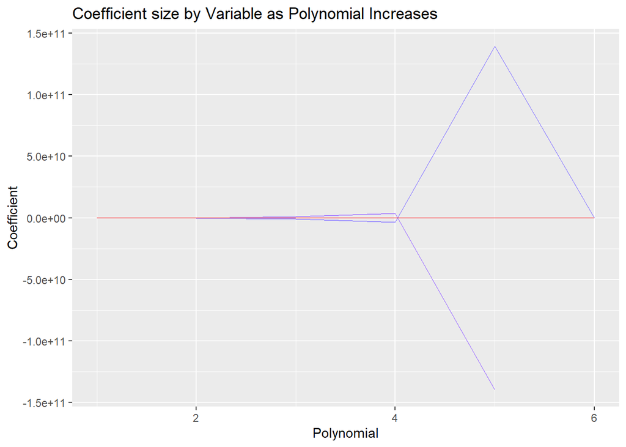

### Question 2: To what extent do total current assets, shares outstanding, and share prices drive change in earnings per share from operations across these leading companies in the dataset? Construct linear regression model using opepsq as the response and actq, cshoq, and prccq as the predictors.

To assess the extent to which total current assets (actq), shares outstanding (cshoq), and share prices (prccq) influence earnings per share from operations (opepsq) across leading companies in the Dow Jones Industrial Index, we constructed three competing multiple linear regression models, each incorporating different transformations of the response and predictors. These models allowed us to explore the relationships between these financial variables and earnings per share from operations.

The first model we constructed was a standard multiple linear regression model with opepsq as the response variable and prccq, cshoq, and actq as the predictors. This model assumed a linear relationship between the predictors and earnings per share. Diagnostic plots were generated and depicted below to evaluate the model’s assumptions. The residuals versus fitted values plot indicated that assumptions such as linearity and homoscedasticity (constant variance) were reasonably satisfied for the model. However, the QQ residuals plot revealed a violation of the normality assumption, as the residuals displayed left skewness. This suggests that the distribution of the residuals deviates from normality, which may influence the model’s ability to accurately predict extreme values of opepsq. From the summary statistics of the model down below, we observed that all three predictors—prccq, cshoq, and actq—were statistically significant in predicting opepsq. Specifically, the coefficients for prccq were positive, while cshoq and actq had a negative coefficient. This implies that increases in share prices (prccq) are associated with increases in earnings per share, whereas a decreases in shares outstanding (cshoq) and total current assets (actq) is linked to an increases in earnings per share. The model explained 49.1% of the variance in opepsq, with an adjusted R-squared of 0.4904, indicating a moderate fit. The residual standard error of 0.8074 on 2,431 degrees of freedom suggests that the typical size of residuals for predictions made by this model is 0.8074, which is relatively large considering the scale of opepsq. This suggests that there is room for improvement in the model’s accuracy. Additionally, the summary statistics down below provided p-values for statistical tests, including both the ANOVA test and individual t-tests. The overall model was highly significant, as indicated by the ANOVA F-statistic of 781.6 (on 3 and 2,431 degrees of freedom) and a p-value of less than 2.2e-16.

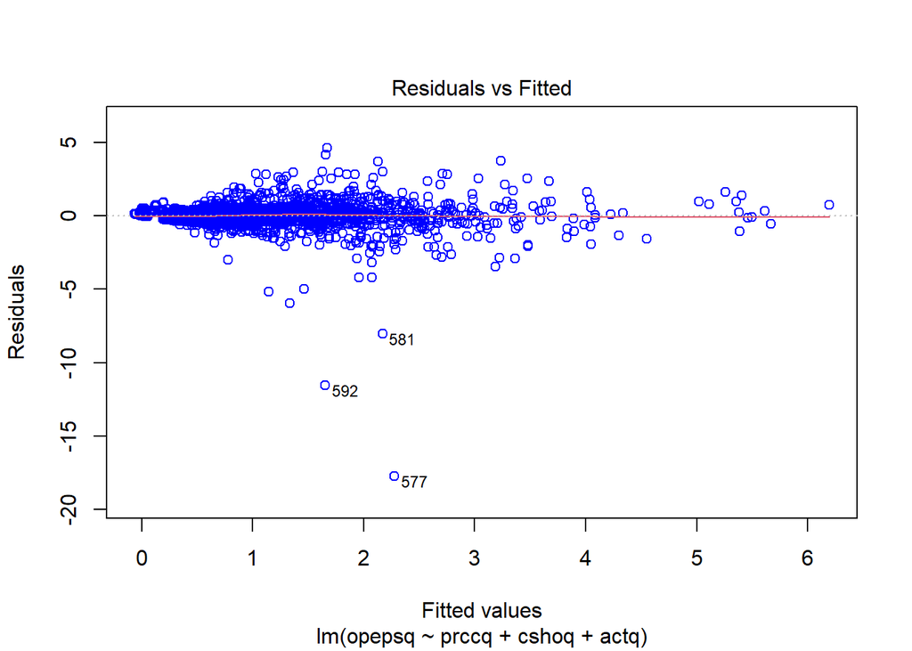

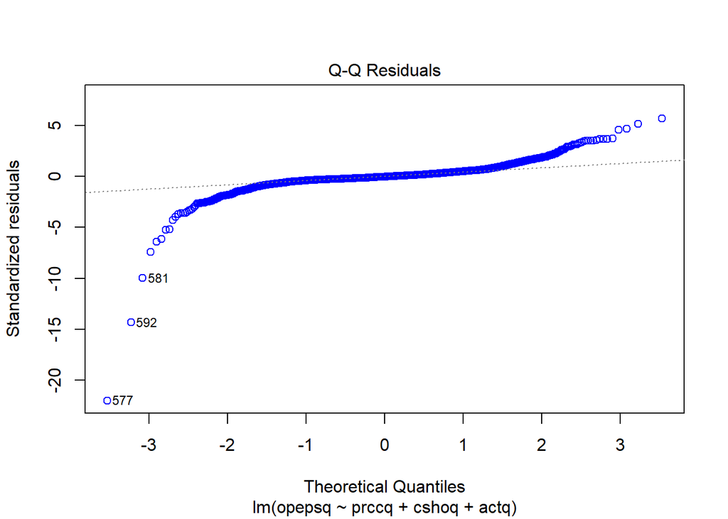

```
##
## Call:
## lm(formula = opepsq ~ prccq + cshoq + actq, data = modeling_DowJones)
##
## Residuals:
##      Min       1Q   Median       3Q      Max
## -17.7386  -0.2141  -0.0191   0.2383   4.6090
##
## Coefficients:
##               Estimate Std. Error t value Pr(>|t|)
## (Intercept)  2.820e-01  3.106e-02   9.079  < 2e-16 ***
## prccq        1.043e-02  2.612e-04  39.929  < 2e-16 ***
## cshoq       -1.259e-11  4.301e-12  -2.927  0.00346 **
## actq        -1.877e-12  6.667e-13  -2.815  0.00491 **
## ---
## Signif. codes:  0 '***' 0.001 '**' 0.01 '*' 0.05 '.' 0.1 ' ' 1
##
## Residual standard error: 0.8074 on 2431 degrees of freedom
##   (390 observations deleted due to missingness)
## Multiple R-squared:  0.491,  Adjusted R-squared:  0.4904
## F-statistic: 781.6 on 3 and 2431 DF,  p-value: < 2.2e-16
```

The second model we constructed attempted to address the normality issue observed in Model 1 by applying a transformation to the response variable (opepsq). Specifically, we applied a 1.1 power transformation to stabilize the variance and improve the normality of the residuals. The diagnostic plots for Model 2 depicted below indicated that the linearity assumption was satisfied (from residuals versus fitted plot), and the normality assumption showed improvement (from QQ residuals plot), as the residuals no longer exhibited left skewness. However, the residuals versus fitted values plot revealed some issues with constant variance, as indicated by a “fan shape” pattern, suggesting heteroscedasticity. The summary statistics for Model 2 down below showed that the predictors prccq and cshoq remained statistically significant, with prccq having a positive coefficient and cshoq having a negative coefficient. While the coefficient for actq was positive but the variable is not statistically significant at the 0.05 level (p-value = 0.1). This suggests that share prices (prccq) and shares outstanding (cshoq) continue to be strong predictors of earnings per share from operations, while total current assets (actq) showed a weaker relationship. Model 2 explained a larger portion of the variance in opepsq, with an adjusted R-squared of 0.6754, representing a notable improvement over Model 1. The residual standard error of 0.674 indicates a smaller typical residual for prediction compared to Model 1, suggesting a better fit. The overall model was highly significant based on the ANOVA test, with an F-statistic of 1630 (on 3 and 2,345 degrees of freedom) and a p-value of less than 2.2e-16.

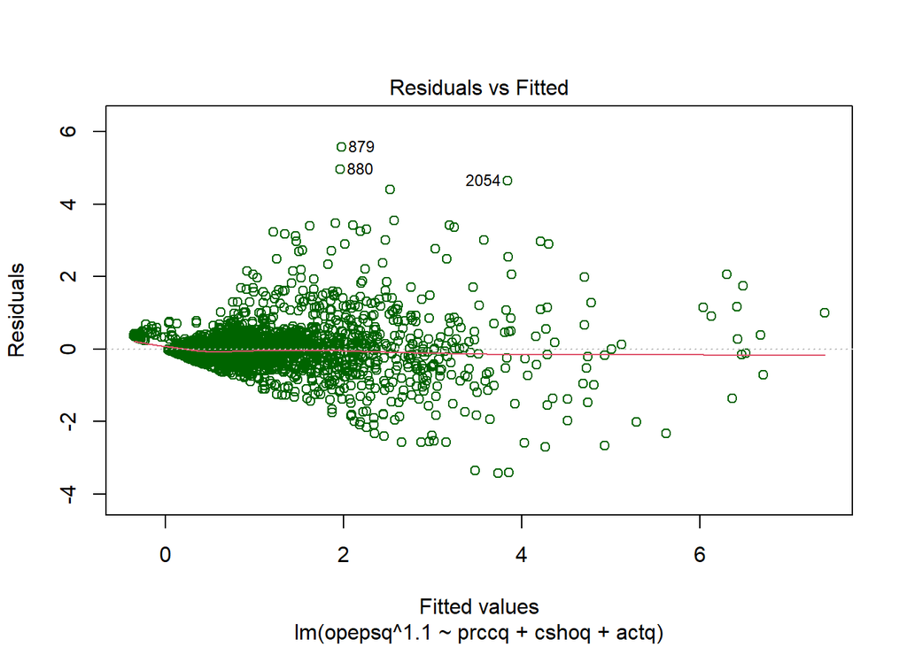

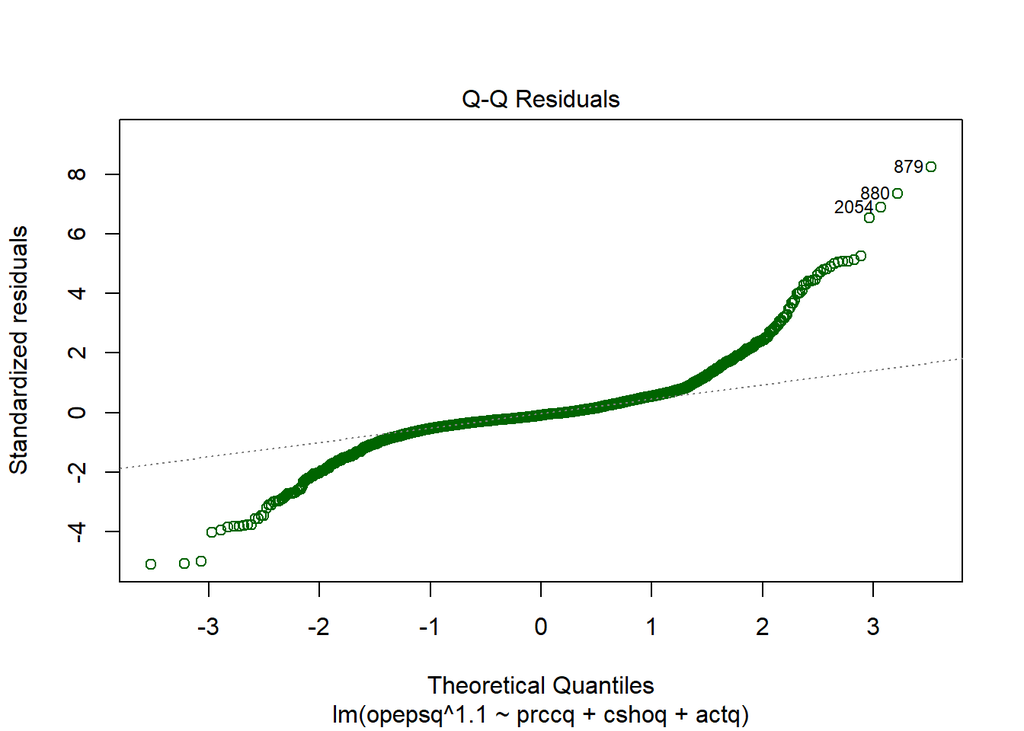

```
##
## Call:
## lm(formula = opepsq^1.1 ~ prccq + cshoq + actq, data = modeling_DowJones)
##
## Residuals:
##     Min      1Q  Median      3Q     Max
## -3.4346 -0.2439 -0.0600  0.1987  5.5696
##
## Coefficients:
##               Estimate Std. Error t value Pr(>|t|)
## (Intercept)  2.135e-01  2.632e-02   8.113 7.86e-16 ***
## prccq        1.219e-02  2.198e-04  55.452  < 2e-16 ***
## cshoq       -2.549e-11  3.669e-12  -6.949 4.75e-12 ***
## actq         9.476e-13  5.766e-13   1.643      0.1
## ---
## Signif. codes:  0 '***' 0.001 '**' 0.01 '*' 0.05 '.' 0.1 ' ' 1
##
## Residual standard error: 0.674 on 2345 degrees of freedom
##   (476 observations deleted due to missingness)
## Multiple R-squared:  0.6758, Adjusted R-squared:  0.6754
## F-statistic:  1630 on 3 and 2345 DF,  p-value: < 2.2e-16
```

We constructed the third model (Model 3) to assess the impact of including interaction terms between the predictors. Specifically, we incorporated interactions between prccq and cshoq, prccq and actq, as well as cshoq and actq. Furthermore, we transform the response variable opepsq by a power of square root. The diagnostic plots for Model 3 depicted down below indicated that the linearity assumption was quite satisfied, and the constant variance assumption was quite reasonable, as the residuals versus fitted values plot showed that residual points were randomly scattered above and below the zero line in a band of relatively constant width. The normality of the residuals showed slight left skewness from the QQ residuals plot, but this was minimal and did not appear to significantly affect the model’s fit. The summary statistics for Model 3 down below revealed mixed effects from the interaction terms. While the main effects of prccq, cshoq, and actq remained highly significant, with positive coefficients for prccq and actq and a negative coefficient for cshoq, the interaction terms showed varying levels of significance. Specifically, the interaction between prccq and actq was highly significant, suggesting that the interaction between share prices and total current assets significantly influences earnings per share. However, the interactions between prccq and cshoq and between cshoq and actq were not statistically significant (p-value not less than 0.05), implying that these terms do not contribute substantial predictive power to the model. Model 3 explained 70.52% of the variance in the transformed opepsq, with an adjusted R-squared of 0.7044, indicating an improvement over Model 2 and Model 1. The residual standard error of 0.2475 suggests that the typical size of the residuals for prediction made by this model is 0.2475, which is smaller compared to the previous two models, reflecting a better overall fit. The model was highly significant, as shown by the ANOVA test, with an F-statistic of 933.7 (on 6 and 2,342 degrees of freedom) and a p-value of less than 2.2e-16.

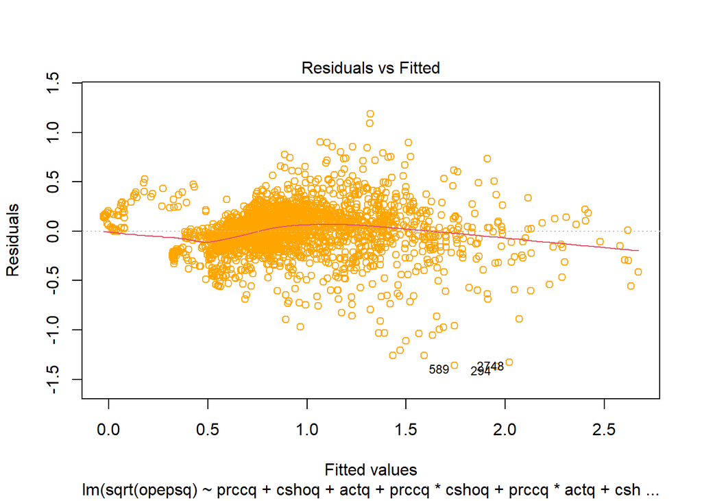

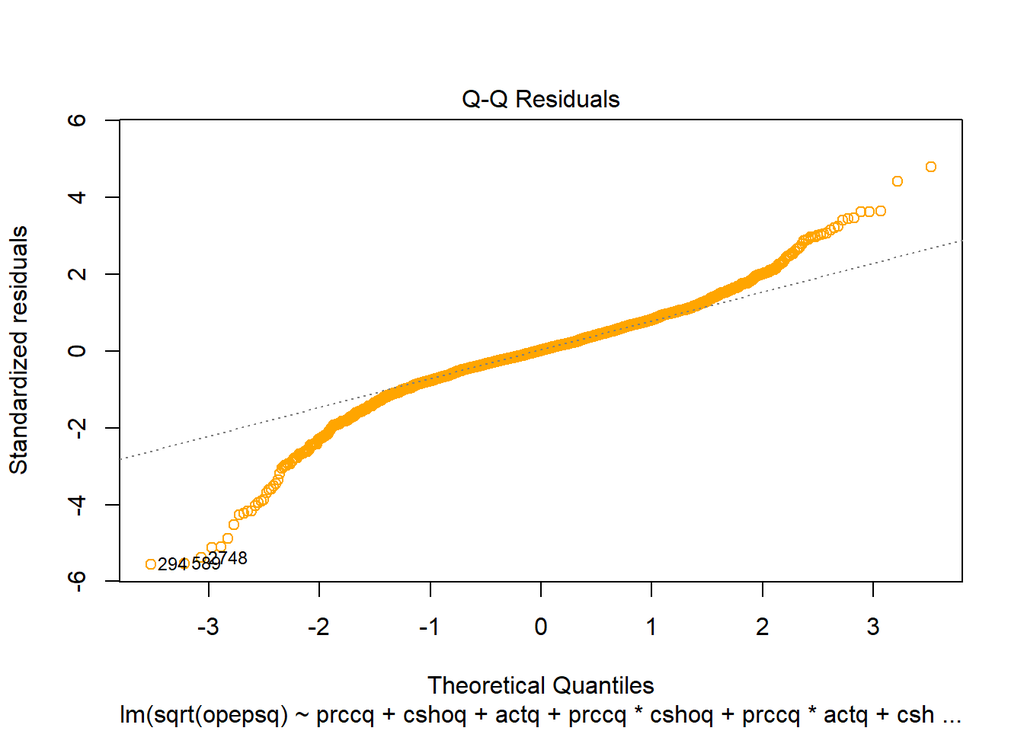

```
##
## Call:
## lm(formula = sqrt(opepsq) ~ prccq + cshoq + actq + prccq * cshoq +
##     prccq * actq + cshoq * actq, data = modeling_DowJones)
##
## Residuals:
##      Min       1Q   Median       3Q      Max
## -1.37216 -0.11538  0.00459  0.13448  1.18712
##
## Coefficients:
##               Estimate Std. Error t value Pr(>|t|)
## (Intercept)  5.142e-01  1.495e-02  34.403   <2e-16 ***
## prccq        5.273e-03  1.135e-04  46.469   <2e-16 ***
## cshoq       -2.578e-11  1.879e-12 -13.721   <2e-16 ***
## actq         6.087e-12  4.268e-13  14.263   <2e-16 ***
## prccq:cshoq -4.733e-14  3.464e-14  -1.366    0.172
## prccq:actq  -2.757e-14  2.059e-15 -13.389   <2e-16 ***
## cshoq:actq  -2.145e-23  4.113e-23  -0.522    0.602
## ---
## Signif. codes:  0 '***' 0.001 '**' 0.01 '*' 0.05 '.' 0.1 ' ' 1
##
## Residual standard error: 0.2475 on 2342 degrees of freedom
##   (476 observations deleted due to missingness)
## Multiple R-squared:  0.7052, Adjusted R-squared:  0.7044
## F-statistic: 933.7 on 6 and 2342 DF,  p-value: < 2.2e-16
```

In conclusion, the three models constructed to predict earnings per share from operations (opepsq) demonstrate that share prices (prccq), shares outstanding (cshoq), and total current assets (actq) are significant predictors of opepsq. All three models showed a moderate R-squared value, with Model 3 achieving the highest explanatory power, suggesting that while these predictors are important, they only account for a portion of the variance in earnings per share. This indicates that other factors, not captured in these models, may also contribute to explaining the variability in opepsq. The inclusion of interaction terms in Model 3 improved the model’s fit, although not all interactions were statistically significant. The findings suggest that while the relationships between these financial variables and earnings per share are robust, further exploration of additional factors and more complex modeling approaches may be needed to fully capture the dynamics of earnings performance across these companies.

# CONCLUSION

We believe our research to be very applicable in the financial sector with a multitude of insights and applications. By finding the linearity between certain price indicators and stock price, we are able to gauge how investors value growing, volatile companies and the specifics they are interested in. And while we understand the financial market is chaotic by nature, our model can be used as an additional data point for decision-making. By understanding the variability of opepsq, we are able to identify the key metrics that influence operational performance and profitability, allowing companies to make informed business decisions. While our dataset was relatively comprehensive, the vast number of potential financial indicators means we are more likely than not to have all relevant variables. This fact also impacts the quality of our model and finding a relevant variable could greatly increase the predictive power. To continue, we would look into understanding the reasons behind the coefficient of the third polynomial being negative and identifying additional indicators that could greatly account for the remaining 29.48% of the variability in opepsq.